# Lesson 4

### Coord_trans()

Notes:

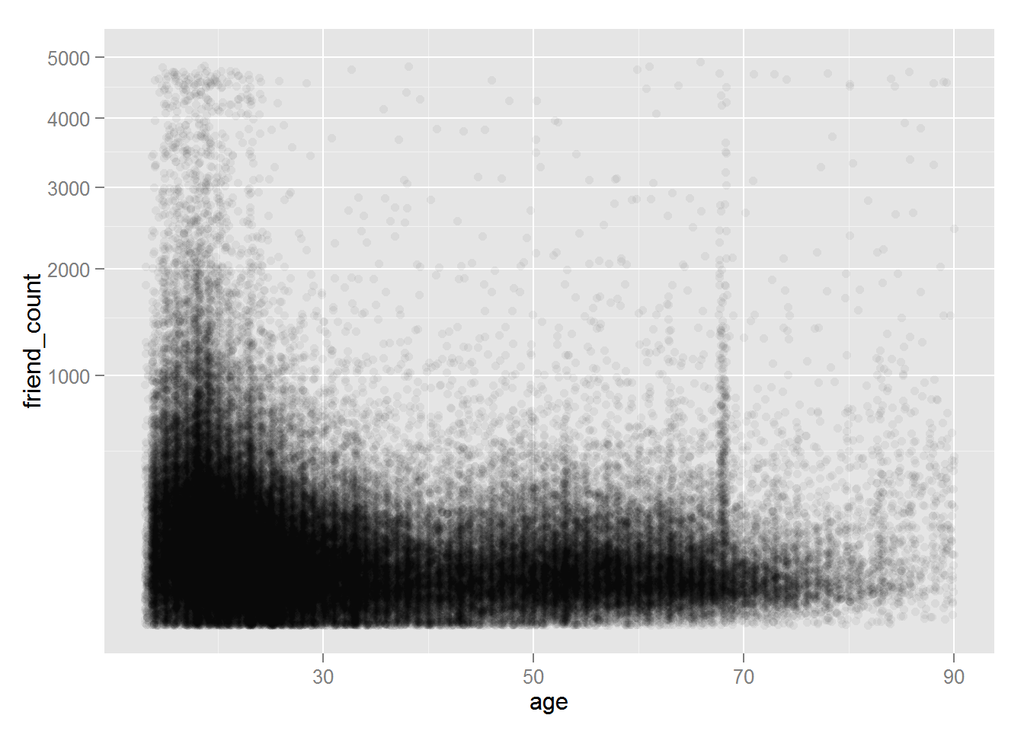

```r
#?coord_trans
ggplot(pf,aes(x=age,y=friend_count)) + geom_jitter(alpha=1/20) + xlim(13,90) +
  ylim(1,5000) + coord_trans(y ="sqrt")
```

#### Look up the documentation for coord_trans() and add a layer to the plot that transforms friend_count using the square root function. Create your plot!

### Alpha and Jitter

Notes:

```r
summary(pf$friendships_initiated)
```

```
##    Min. 1st Qu.  Median    Mean 3rd Qu.    Max.
##     0.0    17.0    46.0   107.5   117.0  4144.0
```

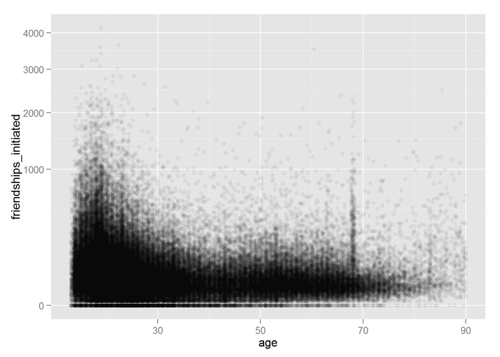

```r
ggplot(pf,aes(x=age,y=friendships_initiated)) + geom_jitter(alpha = 1/20,position = position_jitter(h = 0)) + coord_trans(y="sqrt") +
  xlim(13,90)
```

### Overplotting and Domain Knowledge

Notes:

### Conditional Means

Notes:

```r
library(dplyr)
pf_summarise <- pf %>% group_by(age) %>% summarise(friend_mean = mean(friend_count), friend_median = median(friend_count),n = n())

pf_summarise
```

```
## Source: local data frame [101 x 4]
##
##      age friend_mean friend_median     n
##    (int)       (dbl)         (dbl) (int)
## 1     13    164.7500          74.0   484
## 2     14    251.3901         132.0  1925
## 3     15    347.6921         161.0  2618
## 4     16    351.9371         171.5  3086
## 5     17    350.3006         156.0  3283
## 6     18    331.1663         162.0  5196
## 7     19    333.6921         157.0  4391
## 8     20    283.4991         135.0  3769
## 9     21    235.9412         121.0  3671
## 10    22    211.3948         106.0  3032
## ..   ...         ...           ...   ...
```

Create your plot!

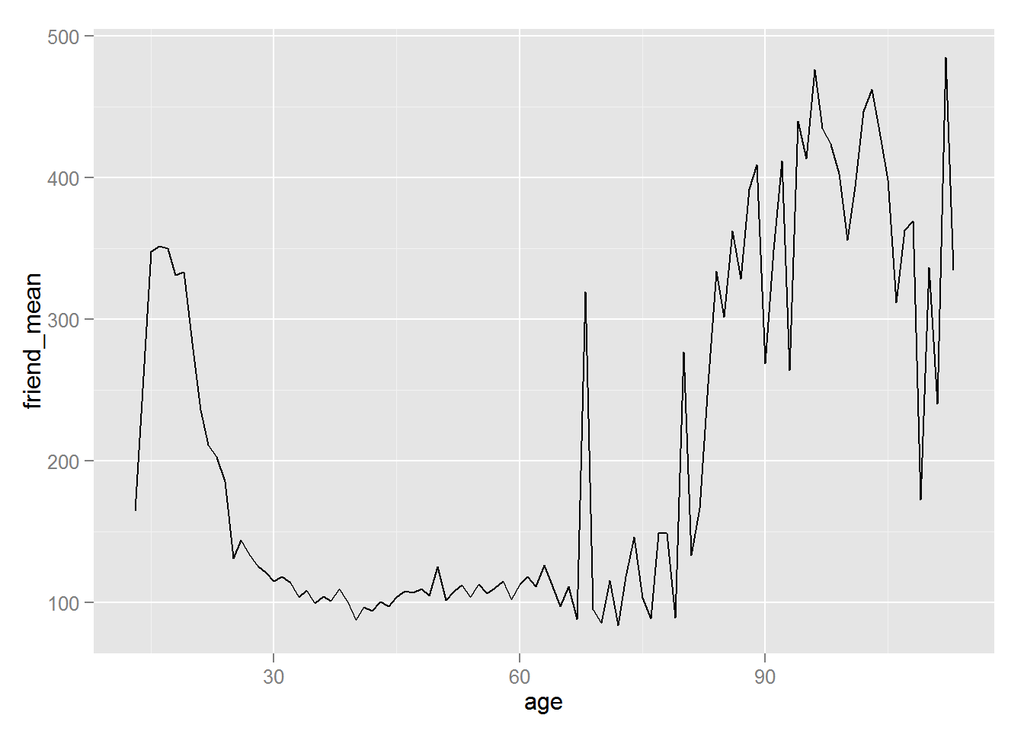

```r
ggplot(pf_summarise,aes(x=age,y=friend_mean)) + geom_line()
```

```r
summary(pf_summarise$friend_mean)
```

```
##    Min. 1st Qu.  Median    Mean 3rd Qu.    Max.
##   84.02  108.20  134.10  212.50  333.80  484.90
```

### Overlaying Summaries with Raw Data

Notes:He we generate a plot which has the orginal friend_count data in **orange**, then we overlay that data with a line plot of the average friend mean, the 10 percent quantile, the 90 percent quantile and the 50 percent quantile.

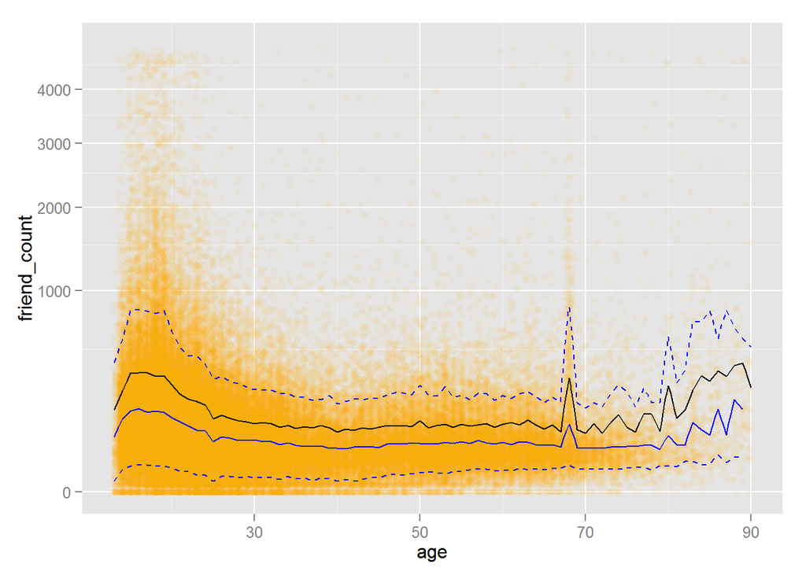

```r
ggplot(pf,aes(x=age,y=friend_count)) + geom_jitter(alpha=1/20,position = position_jitter(h=0),color='orange') + xlim(13,90) + coord_trans(y ="sqrt") +
  geom_line(stat = 'summary',fun.y=mean) +
  geom_line(stat = 'summary',fun.y=quantile,probs=0.1,
            linetype = 2, color='blue') +
  geom_line(stat = 'summary',fun.y=quantile,probs=0.9,
            linetype = 2, color='blue') +
  geom_line(stat = 'summary',fun.y=quantile,probs=0.5,
             color='blue')
```

#### What are some of your observations of the plot?

Response:

### Moira: Histogram Summary and Scatterplot

See the Instructor Notes of this video to download Moira’s paper on perceived audience size and to see the final plot.

Notes:

### Correlation

Notes:

```r
#?cor.test

cor.test(pf$friend_count,pf$age)
```

```
##
##  Pearson's product-moment correlation
##
## data:  pf$friend_count and pf$age
## t = -8.6268, df = 99001, p-value < 2.2e-16
## alternative hypothesis: true correlation is not equal to 0
## 95 percent confidence interval:
##  -0.03363072 -0.02118189
## sample estimates:
##         cor
## -0.02740737
```

Look up the documentation for the cor.test function.

What’s the correlation between age and friend count? Round to three decimal places. Response:

### Correlation on Subsets

Notes:

```r
with(subset(pf,age <=70), cor.test(age, friend_count))
```

```
##
##  Pearson's product-moment correlation
##
## data:  age and friend_count
## t = -52.592, df = 91029, p-value < 2.2e-16
## alternative hypothesis: true correlation is not equal to 0
## 95 percent confidence interval:
##  -0.1780220 -0.1654129
## sample estimates:
##        cor
## -0.1717245
```

### Correlation Methods

Notes:

## Create Scatterplots

Notes:

```r
names(pf)
```

```
##  [1] "userid"                "age"
##  [3] "dob_day"               "dob_year"
##  [5] "dob_month"             "gender"
##  [7] "tenure"                "friend_count"
##  [9] "friendships_initiated" "likes"
## [11] "likes_received"        "mobile_likes"
## [13] "mobile_likes_received" "www_likes"
## [15] "www_likes_received"
```

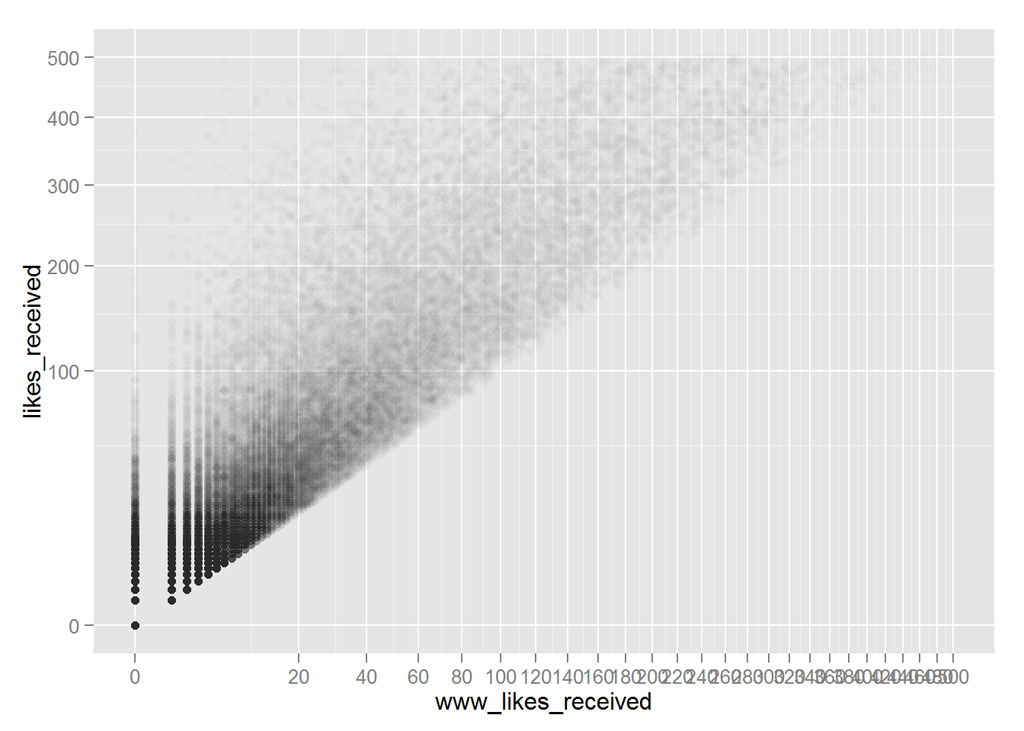

```r
ggplot(pf,aes(x=www_likes_received,y=likes_received)) + geom_jitter(alpha=1/100,position = position_jitter(w=0,h=0)) +
  coord_trans(x="sqrt", y="sqrt") + ylim(0,500) +
  scale_x_continuous(limits=c(0,500),breaks=seq(0,500,20))
```

### Strong Correlations

Notes:

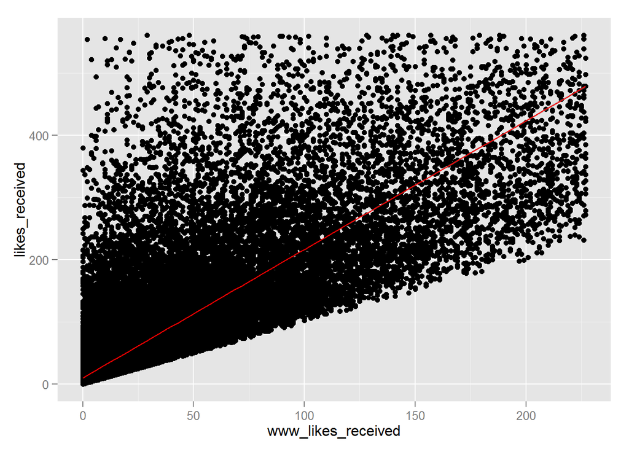

```r
ggplot(pf,aes(x=www_likes_received,y=likes_received)) + geom_point() +
  xlim(0,quantile(pf$www_likes_received,0.95)) +
  ylim(0,quantile(pf$likes_received,0.95)) +
  geom_smooth(method = 'lm', color= 'red')
```

What’s the correlation betwen the two variables? Include the top 5% of values for the variable in the calculation and round to 3 decimal places.

```r
with(pf,cor.test(www_likes_received,likes_received,method='pearson'))
```

```
##
##  Pearson's product-moment correlation
##
## data:  www_likes_received and likes_received
## t = 937.1, df = 99001, p-value < 2.2e-16
## alternative hypothesis: true correlation is not equal to 0
## 95 percent confidence interval:
##  0.9473553 0.9486176
## sample estimates:
##       cor
## 0.9479902
```

Response:

### Moira on Correlation

Notes:

### More Caution with Correlation

Notes:

```r
#install.packages('alr3')
library(alr3)
data("Mitchell")
#?Mitchell
```

Create your plot!

```r
names(Mitchell)
```

```
## [1] "Month" "Temp"
```

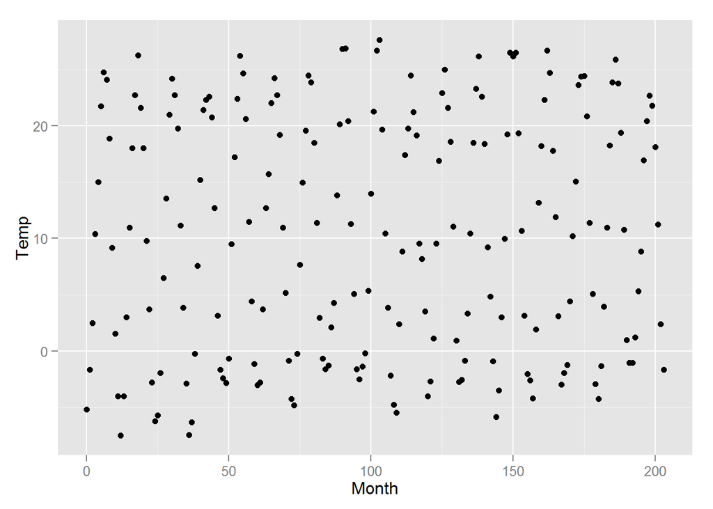

```r
ggplot(Mitchell,aes(x=Month,y=Temp)) + geom_point()
```

### Noisy Scatterplots

1. Take a guess for the correlation coefficient for the scatterplot. 0.02
2. What is the actual correlation of the two variables? (Round to the thousandths place) 0.057

```r
with(Mitchell,cor.test(Month,Temp))
```

```
##
##  Pearson's product-moment correlation
##
## data:  Month and Temp
## t = 0.81816, df = 202, p-value = 0.4142
## alternative hypothesis: true correlation is not equal to 0
## 95 percent confidence interval:
##  -0.08053637  0.19331562
## sample estimates:
##        cor
## 0.05747063
```

### Making Sense of Data

Notes:

```r
summary(Mitchell$Month)
```

```
##    Min. 1st Qu.  Median    Mean 3rd Qu.    Max.
##    0.00   50.75  101.50  101.50  152.20  203.00
```

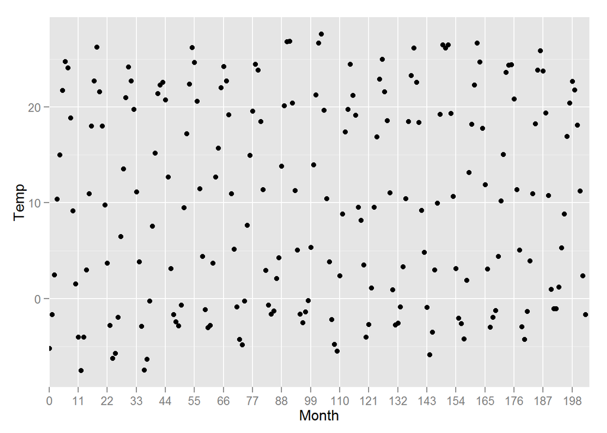

```r
ggplot(Mitchell,aes(x=Month,y=Temp)) + geom_point() +
  scale_x_discrete(breaks=seq(0,203,11))
```

### A New Perspective

What do you notice? Response: There is sort of a cyclic pattern among the points. The peaks are in the middle of the year and lower temperature points are in beginning and end of the year.

Watch the solution video and check out the Instructor Notes! Notes:

### Understanding Noise: Age to Age Months

Notes:

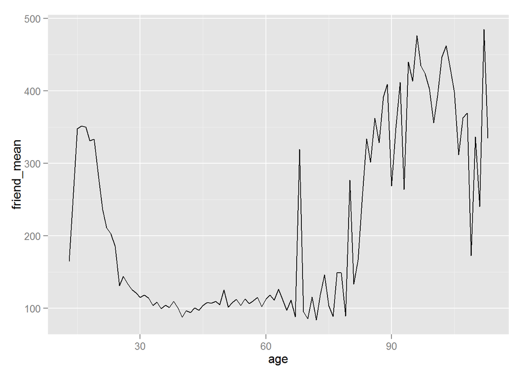

```r
ggplot(pf_summarise,aes(x=age,y=friend_mean)) + geom_line()
```

```r
summary(pf_summarise$friend_mean)
```

```
##    Min. 1st Qu.  Median    Mean 3rd Qu.    Max.
##   84.02  108.20  134.10  212.50  333.80  484.90
```

```r
head(pf_summarise,10)
```

```
## Source: local data frame [10 x 4]
##
##      age friend_mean friend_median     n
##    (int)       (dbl)         (dbl) (int)
## 1     13    164.7500          74.0   484
## 2     14    251.3901         132.0  1925
## 3     15    347.6921         161.0  2618
## 4     16    351.9371         171.5  3086
## 5     17    350.3006         156.0  3283
## 6     18    331.1663         162.0  5196
## 7     19    333.6921         157.0  4391
## 8     20    283.4991         135.0  3769
## 9     21    235.9412         121.0  3671
## 10    22    211.3948         106.0  3032
```

```r
pf_summarise[17:19,]
```

```
## Source: local data frame [3 x 4]
##
##     age friend_mean friend_median     n
##   (int)       (dbl)         (dbl) (int)
## 1    29    120.8182          66.0  1936
## 2    30    115.2080          67.5  1716
## 3    31    118.4599          63.0  1694
```

```r
pf$age_with_months <- pf$age + ((12-pf$dob_month)/12)
```

### Age with Months Means

```r
pf.fc_by_age_months <- pf %>% group_by(age_with_months) %>% summarise(friend_count_mean = mean(friend_count),friend_count_median = median(friend_count), n = n())
```

Programming Assignment

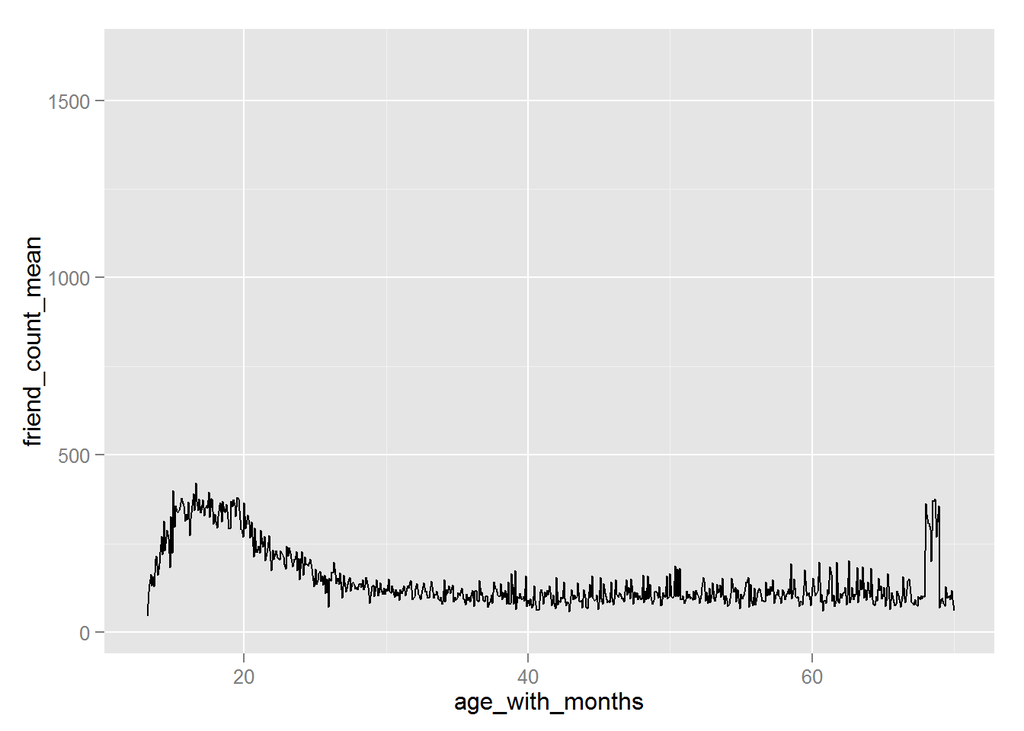

```r
ggplot(pf.fc_by_age_months, aes(x=age_with_months,y=friend_count_mean)) + geom_line() + xlim(13,70)
```

### Noise in Conditional Means

```
## geom_smooth: method="auto" and size of largest group is <1000, so using loess. Use 'method = x' to change the smoothing method.
## geom_smooth: method="auto" and size of largest group is <1000, so using loess. Use 'method = x' to change the smoothing method.
```

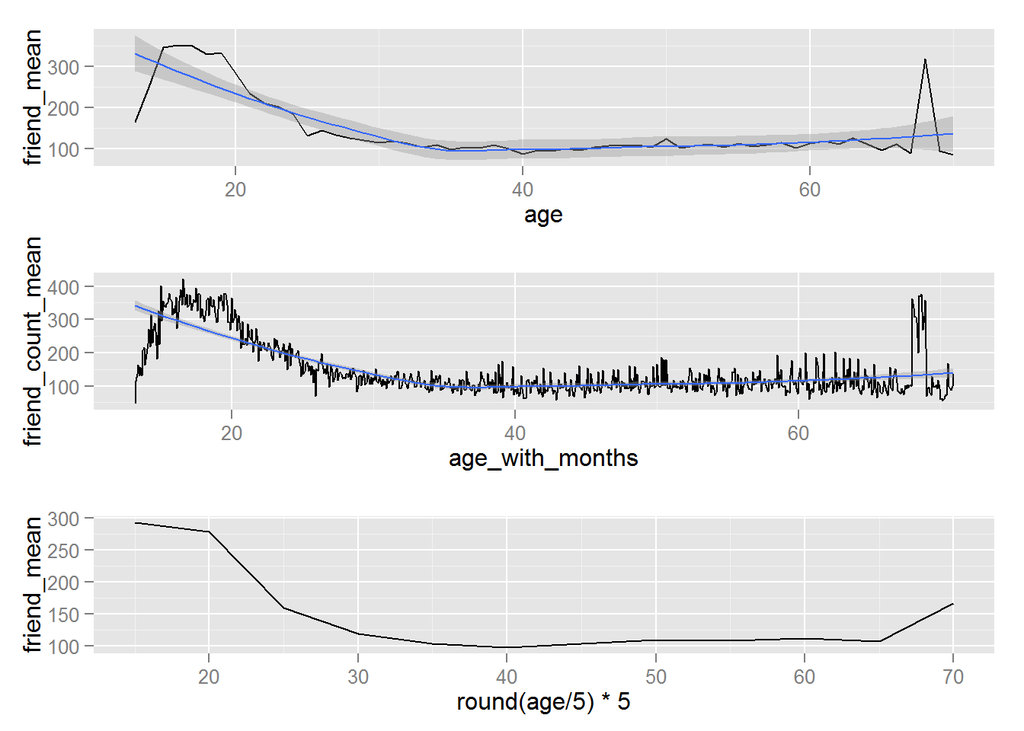

```r
p1 <- ggplot(subset(pf_summarise, age < 71),aes(x=age,y=friend_mean)) + geom_line() + geom_smooth()
p2 <- ggplot(subset(pf.fc_by_age_months, age_with_months < 71), aes(x=age_with_months,y=friend_count_mean)) + geom_line() + geom_smooth()

p3 <- ggplot(subset(pf_summarise, age < 71),aes(x=round(age/5) * 5,y=friend_mean)) + geom_line(stat = 'summary', fun.y=mean)

library(gridExtra)
grid.arrange(p1,p2,p3, ncol = 1)
```

### Smoothing Conditional Means

Notes:

### Which Plot to Choose?

Notes:

### Analyzing Two Variables

Reflection: I learned how to perform Expoloratory Data Analysis on two variables at a time by using scatter plots, and line plots. We saw how using jitter can make the visualization more smoother in scatter plots and changing the scale can allow you to get more insights on data that may be bunched together. We also learned how to view multiple plots on a single graph and how to view them using different line types and colors. We also learned how to view things using conditional means and grouping data by a specific variable to get more insights. Lastly, we discussed how to use the line fitting feature in ggplot to get a better insight of the data, but how can mislead you as well. This was apart of removing the noise in the data. ***

Click **KnitHTML** to see all of your hard work and to have an html page of this lesson, your answers, and your notes!